# Moderated-Nonlinear-Factor-Analysis

Moderated nonlinear factor analysis (MNLFA) has been proposed by Bauer (2017) to assess measurement invariance. The general idea is that parameters within the model (that is, loadings, regressions, intercepts, and (co-)variances) may differ across individuals. These differences are predicted using covariates such as age and gender. For instance, Kolbe et al. (2022) demonstrate MNLFA using the following model:

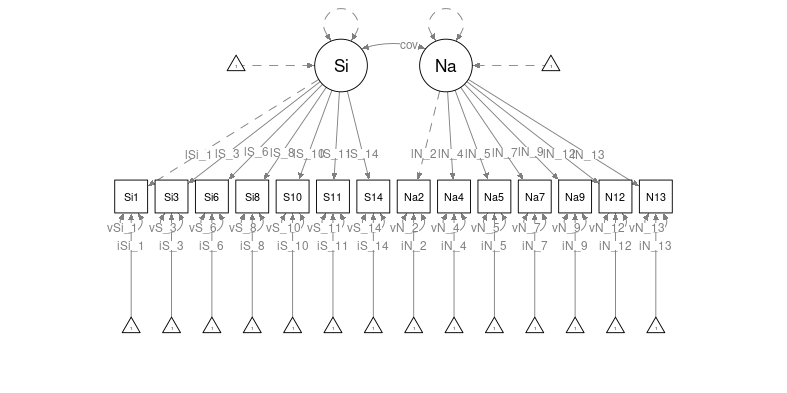

The loading `lSi_1` may differ linearly by age and gender (Kolbe et al., 2022). That is `lSi_1 = lSi0_1 + lSi1_1*Age + lSi2_1*Male`. If `lSi1_1` or `lSi2_1` are non-zero, this suggests measurement non-invariance.

MNLFA is a powerful procedure, but specifying the models can be tedious. Kolbe et al. (2022) provide an in-depth introduction using **OpenMx** using the DS14 data set by Denollet et al. (2013) included in the **mokken** (“Mokken Scale Analysis in R,” 2007) package.

The script for the tutorial by Kolbe et al. (2022) can be found on osf at https://osf.io/527zr. The following pre-processing steps are taken directly from that script:

```r
# code copied from Laura Kolbe, Terrence D. Jorgensen, Suzanne Jak, and Dylan Molenaar
# at https://osf.io/527zr

library(mokken)
## Load data
data("DS14", package="mokken")

## Save as data frame
DS14 <- data.frame(DS14)

## Recode negatively worded items
DS14$Si1 <- 4 - DS14$Si1.
DS14$Si3 <- 4 - DS14$Si3.

## Standardize age
DS14$Age <- (DS14$Age - mean(DS14$Age))/sd(DS14$Age)
# mean-centering age is another option, but caused convergence difficulties with
# this dataset

## Change order of variables
DS14 <- DS14[,c("Male","Age","Si1","Si3","Si6","Si8","Si10","Si11","Si14",
                "Na2","Na4","Na5","Na7","Na9","Na12", "Na13")]

## Check data
head(DS14)
```

```
#>   Male         Age Si1 Si3 Si6 Si8 Si10 Si11 Si14 Na2 Na4 Na5 Na7 Na9 Na12 Na13
#> 1    1  0.03136864   2   2   2   3    2    2    4   3   2   2   3   2    4    2
#> 2    1 -0.44266587   2   1   2   2    2    4    2   0   0   0   0   0    3    0
#> 3    1 -0.82189349   3   3   2   2    2    2    1   3   1   1   2   2    1    1
#> 4    1 -0.63227968   2   2   1   2    3    1    1   3   0   0   0   1    1    0
#> 5    1  0.03136864   2   3   2   3    3    2    3   2   2   2   3   2    3    1
#> 6    0 -0.06343826   0   0   0   0    0    0    0   3   1   2   1   2    4    2
```

## Model specification

We want to specify the configural model outlined in Kolbe et al. (2022). In this model, all loadings, intercepts, variances and co-variances are predicted with the covariates `Age` and `Male`. The only parameter that is constant across all subjects are the latent variances of `Si` and `Na`, which are fixed to 1 for scaling.

For demonstrative purposes, we will first set up a confirmatory factor analysis without the `Age` and `Male` covariates. Using **mxsem**, the syntax could look as follows:

```r
cfa_syntax <- "

# loadings
Si =~ lSi_1*Si1  +
      lSi_3*Si3  +
      lSi_6*Si6  +
      lSi_8*Si8  +
      lSi_10*Si10 +
      lSi_11*Si11 +
      lSi_14*Si14

Na =~ lNa_2*Na2  +
      lNa_4*Na4  +
      lNa_5*Na5  +
      lNa_7*Na7  +
      lNa_9*Na9 +
      lNa_12*Na12 +
      lNa_13*Na13

# latent variances and covariances
Si ~~ 1*Si
Na ~~ 1*Na + cov*Si

# manifest variances
Si1  ~~ vSi_1*Si1
Si3  ~~ vSi_3*Si3
Si6  ~~ vSi_6*Si6
Si8  ~~ vSi_8*Si8
Si10 ~~ vSi_10*Si10
Si11 ~~ vSi_11*Si11
Si14 ~~ vSi_14*Si14

Na2  ~~ vNa_2*Na2
Na4  ~~ vNa_4*Na4
Na5  ~~ vNa_5*Na5
Na7  ~~ vNa_7*Na7
Na9  ~~ vNa_9*Na9
Na12 ~~ vNa_12*Na12
Na13 ~~ vNa_13*Na13

# intercepts
Si1  ~ iSi_1*1
Si3  ~ iSi_3*1
Si6  ~ iSi_6*1
Si8  ~ iSi_8*1
Si10 ~ iSi_10*1
Si11 ~ iSi_11*1
Si14 ~ iSi_14*1

Na2  ~ iNa_2*1
Na4  ~ iNa_4*1
Na5  ~ iNa_5*1
Na7  ~ iNa_7*1
Na9  ~ iNa_9*1
Na12 ~ iNa_12*1
Na13 ~ iNa_13*1
"
```

We want to predict each and every parameter in this model using `Age` and `Male`.

- `lSi_1 = lSi0_1 + lSi1_1*Age + lSi2_1*Male`
- `lSi_3 = lSi0_3 + lSi1_3*Age + lSi2_3*Male`
- …
- `iNa_4 = iNa0_4 + iNa1_4*Age + iNa2_4*Male`
- …

With **mxsem**, this can be implemented as follows:

```r
mnlfa_syntax <- "
==== MNLFA ====

SI =~ {lSi_1  := lSi0_1  + lSi1_1*data.Age  + lSi2_1*data.Male }*Si1  +
      {lSi_3  := lSi0_3  + lSi1_3*data.Age  + lSi2_3*data.Male }*Si3  +
      {lSi_6  := lSi0_6  + lSi1_6*data.Age  + lSi2_6*data.Male }*Si6  +
      {lSi_8  := lSi0_8  + lSi1_8*data.Age  + lSi2_8*data.Male }*Si8  +
      {lSi_10 := lSi0_10 + lSi1_10*data.Age + lSi2_10*data.Male}*Si10 +
      {lSi_11 := lSi0_11 + lSi1_11*data.Age + lSi2_11*data.Male}*Si11 +
      {lSi_14 := lSi0_14 + lSi1_14*data.Age + lSi2_14*data.Male}*Si14

NA =~ {lNa_2  := lNa0_2  + lNa1_2*data.Age  + lNa2_2*data.Male }*Na2  +
      {lNa_4  := lNa0_4  + lNa1_4*data.Age  + lNa2_4*data.Male }*Na4  +
      {lNa_5  := lNa0_5  + lNa1_5*data.Age  + lNa2_5*data.Male }*Na5  +
      {lNa_7  := lNa0_7  + lNa1_7*data.Age  + lNa2_7*data.Male }*Na7  +
      {lNa_9  := lNa0_9  + lNa1_9*data.Age  + lNa2_9*data.Male }*Na9  +
      {lNa_12 := lNa0_12 + lNa1_12*data.Age + lNa2_12*data.Male}*Na12 +
      {lNa_13 := lNa0_13 + lNa1_13*data.Age + lNa2_13*data.Male}*Na13

SI ~~ 1*SI
NA ~~ 1*NA + {cov := cov0  + cov1*data.Age  + cov2*data.Male }*SI

Si1  ~~ {vSi_1  := exp(vSi0_1  + vSi1_1*data.Age  + vSi2_1*data.Male )}*Si1
Si3  ~~ {vSi_3  := exp(vSi0_3  + vSi1_3*data.Age  + vSi2_3*data.Male )}*Si3
Si6  ~~ {vSi_6  := exp(vSi0_6  + vSi1_6*data.Age  + vSi2_6*data.Male )}*Si6
Si8  ~~ {vSi_8  := exp(vSi0_8  + vSi1_8*data.Age  + vSi2_8*data.Male )}*Si8
Si10 ~~ {vSi_10 := exp(vSi0_10 + vSi1_10*data.Age + vSi2_10*data.Male)}*Si10
Si11 ~~ {vSi_11 := exp(vSi0_11 + vSi1_11*data.Age + vSi2_11*data.Male)}*Si11
Si14 ~~ {vSi_14 := exp(vSi0_14 + vSi1_14*data.Age + vSi2_14*data.Male)}*Si14

Na2  ~~ {vNa_2  := exp(vNa0_2  + vNa1_2*data.Age  + vNa2_2*data.Male )}*Na2
Na4  ~~ {vNa_4  := exp(vNa0_4  + vNa1_4*data.Age  + vNa2_4*data.Male )}*Na4
Na5  ~~ {vNa_5  := exp(vNa0_5  + vNa1_5*data.Age  + vNa2_5*data.Male )}*Na5
Na7  ~~ {vNa_7  := exp(vNa0_7  + vNa1_7*data.Age  + vNa2_7*data.Male )}*Na7
Na9  ~~ {vNa_9  := exp(vNa0_9  + vNa1_9*data.Age  + vNa2_9*data.Male )}*Na9
Na12 ~~ {vNa_12 := exp(vNa0_12 + vNa1_12*data.Age + vNa2_12*data.Male)}*Na12
Na13 ~~ {vNa_13 := exp(vNa0_13 + vNa1_13*data.Age + vNa2_13*data.Male)}*Na13

Si1  ~ {iSi_1  := iSi0_1  + iSi1_1*data.Age  + iSi2_1*data.Male }*1
Si3  ~ {iSi_3  := iSi0_3  + iSi1_3*data.Age  + iSi2_3*data.Male }*1
Si6  ~ {iSi_6  := iSi0_6  + iSi1_6*data.Age  + iSi2_6*data.Male }*1
Si8  ~ {iSi_8  := iSi0_8  + iSi1_8*data.Age  + iSi2_8*data.Male }*1
Si10 ~ {iSi_10 := iSi0_10 + iSi1_10*data.Age + iSi2_10*data.Male}*1
Si11 ~ {iSi_11 := iSi0_11 + iSi1_11*data.Age + iSi2_11*data.Male}*1
Si14 ~ {iSi_14 := iSi0_14 + iSi1_14*data.Age + iSi2_14*data.Male}*1

Na2  ~ {iNa_2  := iNa0_2  + iNa1_2*data.Age  + iNa2_2*data.Male }*1
Na4  ~ {iNa_4  := iNa0_4  + iNa1_4*data.Age  + iNa2_4*data.Male }*1
Na5  ~ {iNa_5  := iNa0_5  + iNa1_5*data.Age  + iNa2_5*data.Male }*1
Na7  ~ {iNa_7  := iNa0_7  + iNa1_7*data.Age  + iNa2_7*data.Male }*1
Na9  ~ {iNa_9  := iNa0_9  + iNa1_9*data.Age  + iNa2_9*data.Male }*1
Na12 ~ {iNa_12 := iNa0_12 + iNa1_12*data.Age + iNa2_12*data.Male}*1
Na13 ~ {iNa_13 := iNa0_13 + iNa1_13*data.Age + iNa2_13*data.Male}*1
"
```

Note how each parameter is redefined exactly as outlined above. However, there are some important details:

1. The variance parameters (e.g., `vNa_2`), have been transformed with an `exp`-function. This exponential function ensures that variances are always positive.
2. All transformations must be embraced in curly braces. This ensures that **mxsem** sees them as algebras and knows how to specify them in **OpenMx**.
3. The covariates `Age` and `Male` must be specified with the `data.`-prefix to let **OpenMx** know that the values can be found in the data set.

Finally, we pass the syntax to the `mxsem()`-function to create an **OpenMx** model:

```r
library(mxsem)
mnlfa_model <- mxsem(model = mnlfa_syntax,
                     data = DS14,
                     # we scaled the latent variables manually,
                     # so we will set all automatic scalings to FALSE:
                     scale_loadings = FALSE,
                     scale_latent_variances = FALSE)
```

## Fitting the model

The model can now be fitted using `mxRun()` or `mxTryHard()`.

```r
mnlfa_model <- mxRun(mnlfa_model)
summary(mnlfa_model)
```

**Show summary**

```
#> Summary of MNLFA
#>
#> free parameters:
#>        name         matrix row col      Estimate  Std.Error A
#> 1    lSi0_1 new_parameters   1   1  0.7335132285 0.13036446
#> 2    lSi1_1 new_parameters   1   2 -0.1154254853 0.05220418 !
#> 3    lSi2_1 new_parameters   1   3  0.1400286638 0.13867317
#> 4    lSi0_3 new_parameters   1   4  0.3015782364 0.16686695
#> 5    lSi1_3 new_parameters   1   5 -0.0879323846 0.05923775
#> 6    lSi2_3 new_parameters   1   6  0.4591409519 0.17588023
#> 7    lSi0_6 new_parameters   1   7  0.9194296656 0.15047895
#> 8    lSi1_6 new_parameters   1   8 -0.0706498226 0.04993080
#> 9    lSi2_6 new_parameters   1   9 -0.0979268589 0.15798719
#> 10   lSi0_8 new_parameters   1  10  1.0701237981 0.12879256
#> 11   lSi1_8 new_parameters   1  11  0.0561234419 0.04935080
```

[output cut: 140 more lines]

Checking the regression coefficients `lSi1_1`, `lSi1_2`, … will tell us if there is a linear change across age or if individuals with `Male = 0` differ from individuals with `Male = 1`.

## Plotting Individual Parameters

MNLFA predicts individual parameter values (e.g., `lSi_1`) using definition variables. To get a better picture of the individual parameters, **mxsem** provides the `get_individual_algebra_results` function. This function will compute for each algebra the individual parameters. Depending on the sample size and the number of algebras in the model, this may take some time. Therefore, we will only extract the individual parameter values for `lSi_1` as an example.

```r
lSi_1 <- get_individual_algebra_results(mxModel = mnlfa_model,
                                        algebra_names = "lSi_1",
                                        progress_bar = FALSE)
head(lSi_1$lSi_1)
```

```
#>   person         Age Male algebra_result
#> 1      1  0.03136864    1      0.8699212
#> 2      2 -0.44266587    1      0.9246368
#> 3      3 -0.82189349    1      0.9684093
#> 4      4 -0.63227968    1      0.9465231
#> 5      5  0.03136864    1      0.8699212
#> 6      6 -0.06343826    0      0.7408356
```

The function will return a list with data frames for all requested algebras. Here, the list has only one element: `lSi_1`. The data frame will have fields for the person, the definition variables used in the algebra (`Age` and `Male` in this case) and the person specific parameter (`algebra_result`). We can plot these results as follows:

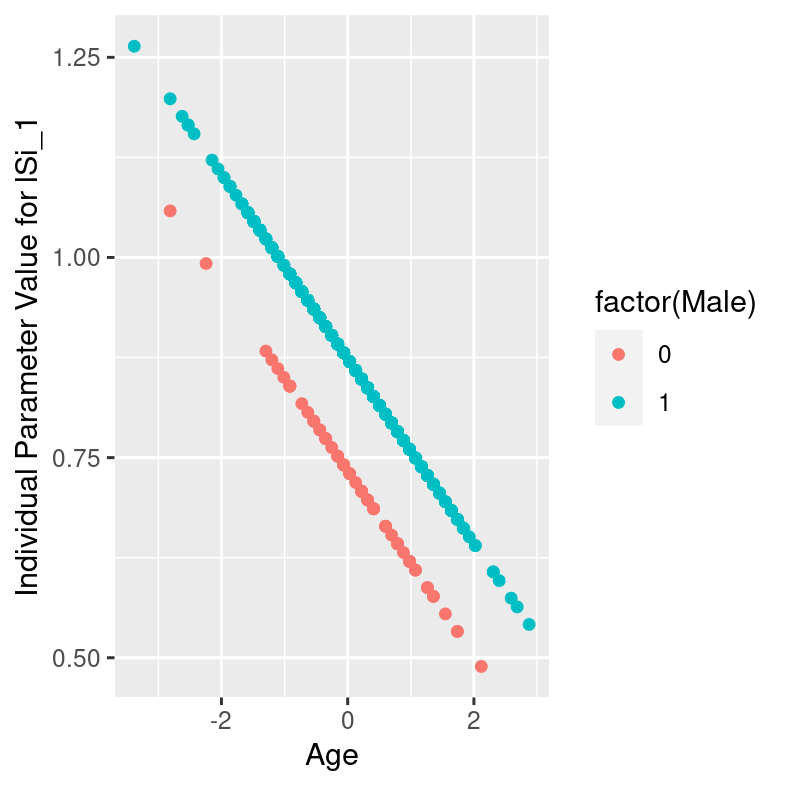

```r
library(ggplot2)
ggplot(data = lSi_1$lSi_1,
       aes(x = Age,
           y = algebra_result,
           color = factor(Male))) +
  ylab("Individual Parameter Value for lSi_1") +
  geom_point()
```

## References

Bauer, D. J. (2017). A more general model for testing measurement invariance and differential item functioning. *Psychological Methods*, *22*(3), 507–526. https://doi.org/10.1037/met0000077

Denollet, J., Pedersen, S. S., Vrints, C. J., & Conraads, V. M. (2013). Predictive Value of Social Inhibition and Negative Affectivity for Cardiovascular Events and Mortality in Patients With Coronary Artery Disease: The Type D Personality Construct. *Psychosomatic Medicine*, *75*(9), 873–881. https://doi.org/10.1097/PSY.0000000000000001

Kolbe, L., Molenaar, D., Jak, S., & Jorgensen, T. D. (2022). Assessing measurement invariance with moderated nonlinear factor analysis using the R package OpenMx. *Psychological Methods*. https://doi.org/10.1037/met0000501

Mokken Scale Analysis in R. (2007). *Journal of Statistical Software*, *20*(11), 1–19.